# 777 Univariado

## Abstenerme de tener relaciones sexuales es la conducta menos riesgosa frente a mi sexualidad

A continuaciï¿½n se presentan las estadï¿½sticas de la variable (`Abstenerme de tener relaciones sexuales es la conducta menos riesgosa frente a mi sexualidad`)

Tabla de Frecuencia

| Categorï¿½a | Frecuencia abs | Frecuencia rel. (%) |
| --- | --- | --- |
| Totalmente De Acuerdo | 127 | 18.57 |
| De Acuerdo | 147 | 21.49 |
| Ni de acuerdo ni en desacuerdo | 157 | 22.95 |
| En Desacuerdo | 113 | 16.52 |
| Totalmente en Desacuerdo | 140 | 20.47 |

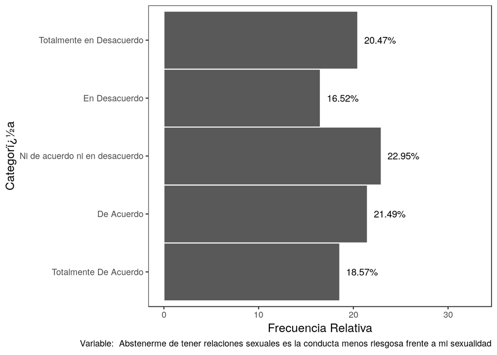

## Un embarazo no deseado es el resultado de una conducta sexual riesgosa.

A continuaciï¿½n se presentan las estadï¿½sticas de la variable (`Un embarazo no deseado es el resultado de una conducta sexual riesgosa.`)

Tabla de Frecuencia

| Categorï¿½a | Frecuencia abs | Frecuencia rel. (%) |
| --- | --- | --- |
| Totalmente De Acuerdo | 206 | 30.12 |
| De Acuerdo | 102 | 14.91 |
| Ni de acuerdo ni en desacuerdo | 155 | 22.66 |
| En Desacuerdo | 139 | 20.32 |
| Totalmente en Desacuerdo | 82 | 11.99 |

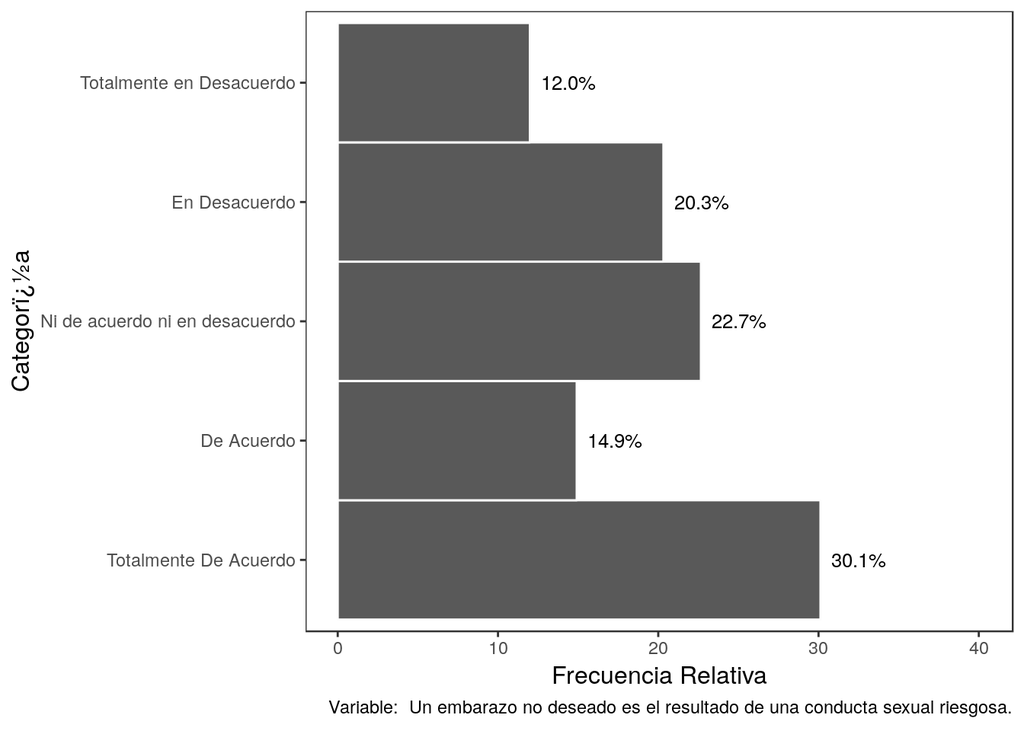

## Tener conductas sexuales de riesgo aumenta la posibilidad de contraer una ETS o ITS.

A continuaciï¿½n se presentan las estadï¿½sticas de la variable (`Tener conductas sexuales de riesgo aumenta la posibilidad de contraer una ETS o ITS.`)

Tabla de Frecuencia

| Categorï¿½a | Frecuencia abs | Frecuencia rel. (%) |
| --- | --- | --- |
| Totalmente De Acuerdo | 215 | 31.43 |
| De Acuerdo | 20 | 2.92 |
| Ni de acuerdo ni en desacuerdo | 36 | 5.26 |
| En Desacuerdo | 398 | 58.19 |
| Totalmente en Desacuerdo | 15 | 2.19 |

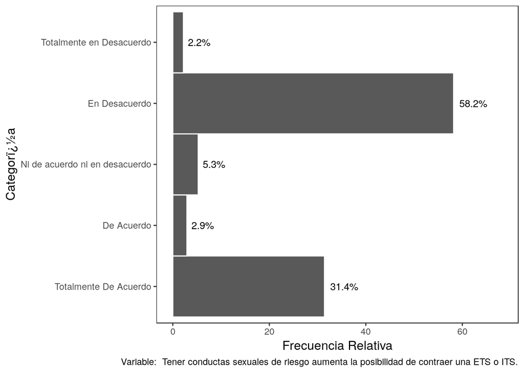

## Al no usar mÃ©todos anticonceptivos he llegado a experimentar susto, miedo de alguna consecuencia (embarazos, ITS, ETS)

A continuaciï¿½n se presentan las estadï¿½sticas de la variable (`Al no usar mÃ©todos anticonceptivos he llegado a experimentar susto, miedo de alguna consecuencia (embarazos, ITS, ETS)`)

Tabla de Frecuencia

| Categorï¿½a | Frecuencia abs | Frecuencia rel. (%) |
| --- | --- | --- |
| Totalmente De Acuerdo | 305 | 44.59 |
| De Acuerdo | 35 | 5.12 |
| Ni de acuerdo ni en desacuerdo | 101 | 14.77 |
| En Desacuerdo | 186 | 27.19 |
| Totalmente en Desacuerdo | 57 | 8.33 |

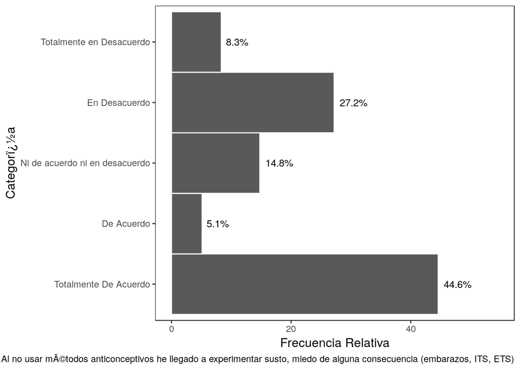

## Realizarme examenes médicos periódicos (pruebas de VIH, citologías, entre otros) es una forma de cuidar mi salud sexual.

A continuaciï¿½n se presentan las estadï¿½sticas de la variable (`Realizarme examenes médicos periódicos (pruebas de VIH, citologías, entre otros) es una forma de cuidar mi salud sexual.`)

Tabla de Frecuencia

| Categorï¿½a | Frecuencia abs | Frecuencia rel. (%) |
| --- | --- | --- |
| Totalmente De Acuerdo | 200 | 29.24 |
| De Acuerdo | 8 | 1.17 |
| Ni de acuerdo ni en desacuerdo | 32 | 4.68 |
| En Desacuerdo | 437 | 63.89 |
| Totalmente en Desacuerdo | 7 | 1.02 |

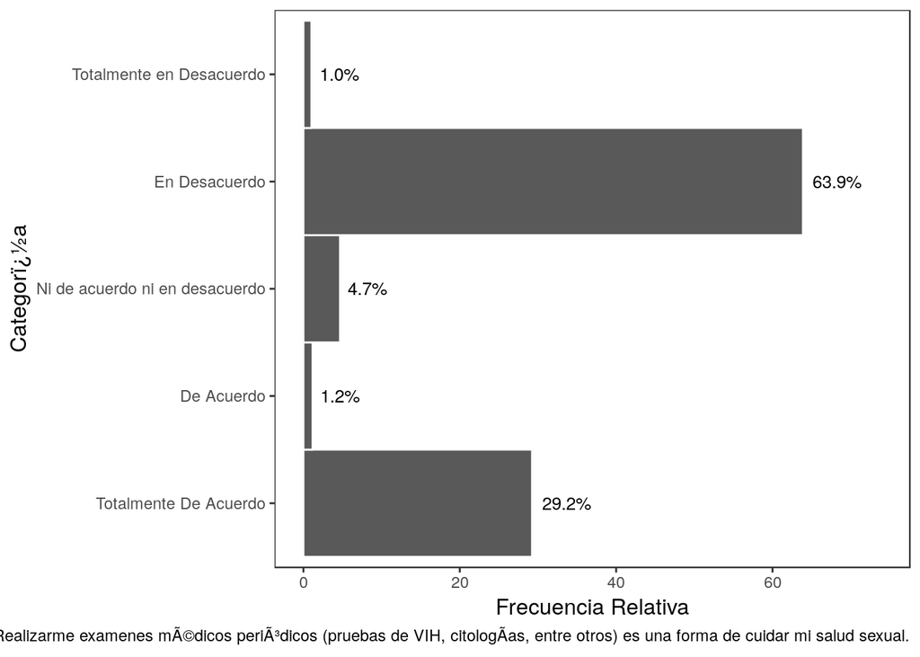

## Cuando he tenido relaciones sexuales riesgosas por prevención tomo o induzco a tomar la pastilla del día después (si aplica).

A continuaciï¿½n se presentan las estadï¿½sticas de la variable (`Cuando he tenido relaciones sexuales riesgosas por prevención tomo o induzco a tomar la pastilla del día después (si aplica).`)

Tabla de Frecuencia

| Categorï¿½a | Frecuencia abs | Frecuencia rel. (%) |
| --- | --- | --- |
| Totalmente De Acuerdo | 193 | 28.22 |
| De Acuerdo | 80 | 11.70 |
| Ni de acuerdo ni en desacuerdo | 214 | 31.29 |
| En Desacuerdo | 85 | 12.43 |
| Totalmente en Desacuerdo | 112 | 16.37 |

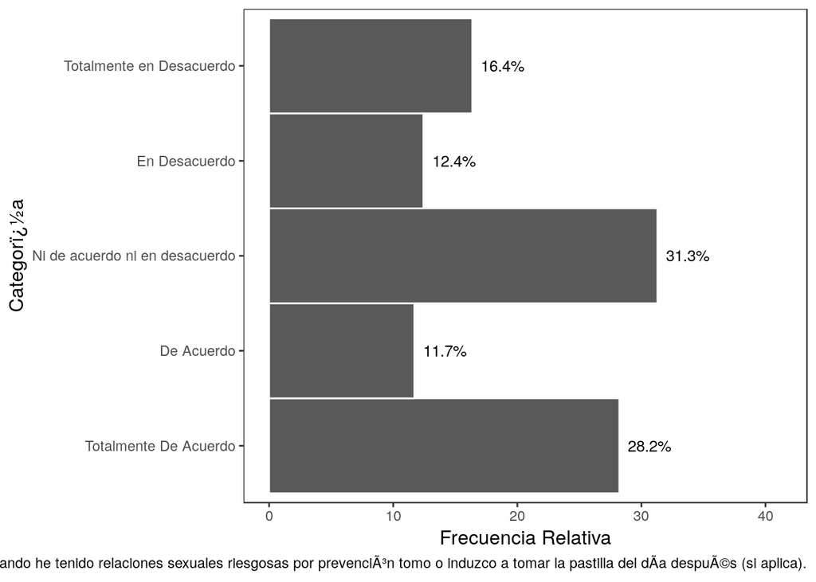

## Entre menos parejas sexuales tenga, mÃ¡s segura es mi sexualidad.

A continuaciï¿½n se presentan las estadï¿½sticas de la variable (`Entre menos parejas sexuales tenga, mÃ¡s segura es mi sexualidad.`)

Tabla de Frecuencia

| Categorï¿½a | Frecuencia abs | Frecuencia rel. (%) |
| --- | --- | --- |
| Totalmente De Acuerdo | 166 | 24.27 |
| De Acuerdo | 139 | 20.32 |
| Ni de acuerdo ni en desacuerdo | 180 | 26.32 |
| En Desacuerdo | 91 | 13.30 |
| Totalmente en Desacuerdo | 108 | 15.79 |

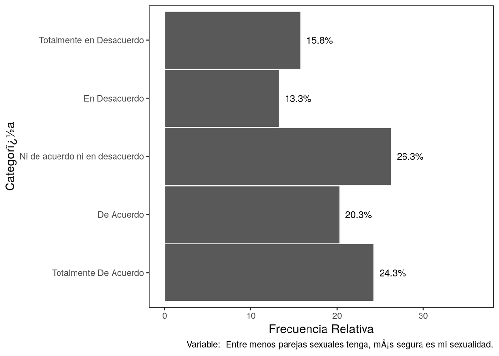

## Con mi (ultima) pareja sentimental no he usado condÃ³n porque me brinda confianza y seguridad.

A continuaciï¿½n se presentan las estadï¿½sticas de la variable (`Con mi (ultima) pareja sentimental no he usado condÃ³n porque me brinda confianza y seguridad.`)

Tabla de Frecuencia

| Categorï¿½a | Frecuencia abs | Frecuencia rel. (%) |
| --- | --- | --- |
| Totalmente De Acuerdo | 215 | 31.43 |
| De Acuerdo | 84 | 12.28 |
| Ni de acuerdo ni en desacuerdo | 96 | 14.04 |
| En Desacuerdo | 197 | 28.80 |
| Totalmente en Desacuerdo | 92 | 13.45 |

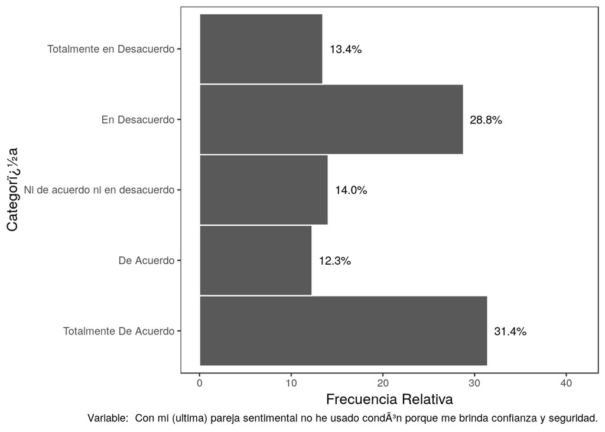

## La infidelidad sexual me parece riesgosa para mi pareja y para mi.

A continuaciï¿½n se presentan las estadï¿½sticas de la variable (`La infidelidad sexual me parece riesgosa para mi pareja y para mi.`)

Tabla de Frecuencia

| Categorï¿½a | Frecuencia abs | Frecuencia rel. (%) |
| --- | --- | --- |
| Totalmente De Acuerdo | 215 | 31.43 |
| De Acuerdo | 62 | 9.06 |
| Ni de acuerdo ni en desacuerdo | 88 | 12.87 |
| En Desacuerdo | 292 | 42.69 |
| Totalmente en Desacuerdo | 27 | 3.95 |

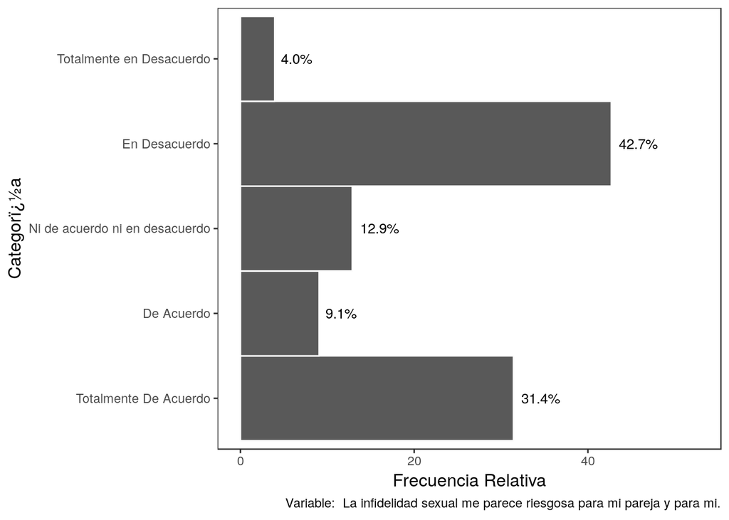

## No tengo problemas en relacionarme sexualmente con una persona a la que reciÃ©n conozco.

A continuaciï¿½n se presentan las estadï¿½sticas de la variable (`No tengo problemas en relacionarme sexualmente con una persona a la que reciÃ©n conozco.`)

Tabla de Frecuencia

| Categorï¿½a | Frecuencia abs | Frecuencia rel. (%) |
| --- | --- | --- |
| Totalmente De Acuerdo | 152 | 22.22 |
| De Acuerdo | 139 | 20.32 |
| Ni de acuerdo ni en desacuerdo | 157 | 22.95 |
| En Desacuerdo | 40 | 5.85 |
| Totalmente en Desacuerdo | 196 | 28.65 |

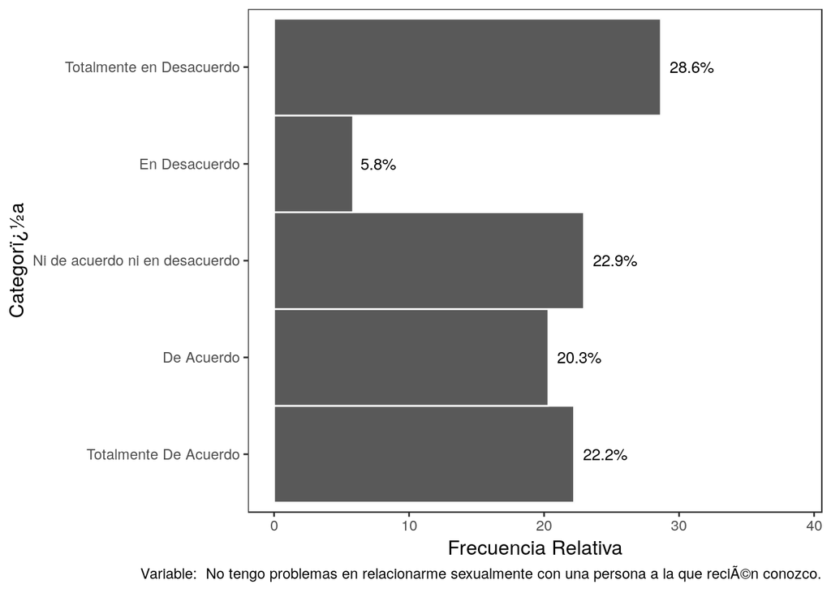

## Conocer la historia sexual de mi pareja me da seguridad a la hora de tener sexo

A continuaciï¿½n se presentan las estadï¿½sticas de la variable (`Conocer la historia sexual de mi pareja me da seguridad a la hora de tener sexo`)

Tabla de Frecuencia

| Categorï¿½a | Frecuencia abs | Frecuencia rel. (%) |
| --- | --- | --- |
| Totalmente De Acuerdo | 267 | 39.04 |
| De Acuerdo | 60 | 8.77 |
| Ni de acuerdo ni en desacuerdo | 117 | 17.11 |
| En Desacuerdo | 204 | 29.82 |
| Totalmente en Desacuerdo | 36 | 5.26 |

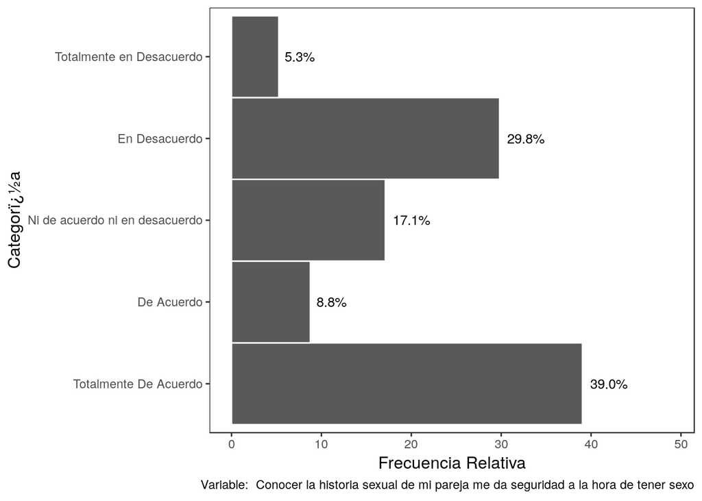

## Evito conductas sexuales de riesgo al ser monogamo.

A continuaciï¿½n se presentan las estadï¿½sticas de la variable (`Evito conductas sexuales de riesgo al ser monogamo.`)

Tabla de Frecuencia

| Categorï¿½a | Frecuencia abs | Frecuencia rel. (%) |
| --- | --- | --- |
| Totalmente De Acuerdo | 179 | 26.17 |
| De Acuerdo | 145 | 21.20 |
| Ni de acuerdo ni en desacuerdo | 182 | 26.61 |
| En Desacuerdo | 99 | 14.47 |
| Totalmente en Desacuerdo | 79 | 11.55 |

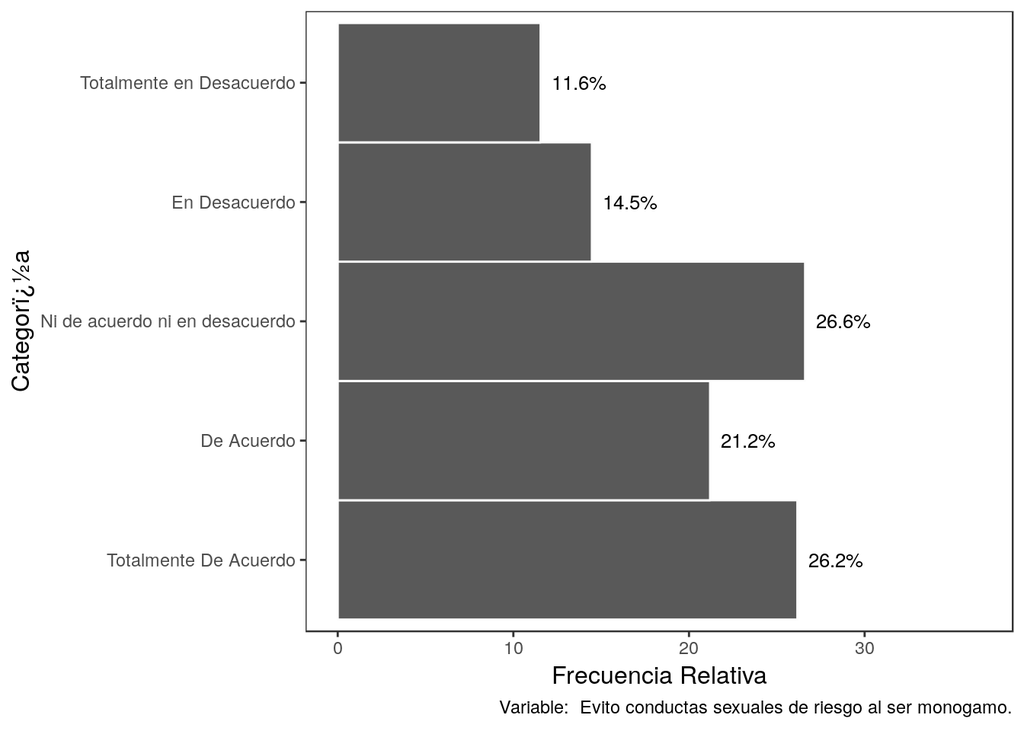

## Considero que corro menos riesgo sexual al tener relaciones solo con personas conocidas.

A continuaciï¿½n se presentan las estadï¿½sticas de la variable (`Considero que corro menos riesgo sexual al tener relaciones solo con personas conocidas.`)

Tabla de Frecuencia

| Categorï¿½a | Frecuencia abs | Frecuencia rel. (%) |
| --- | --- | --- |
| Totalmente De Acuerdo | 236 | 34.50 |
| De Acuerdo | 126 | 18.42 |
| Ni de acuerdo ni en desacuerdo | 131 | 19.15 |
| En Desacuerdo | 124 | 18.13 |
| Totalmente en Desacuerdo | 67 | 9.80 |

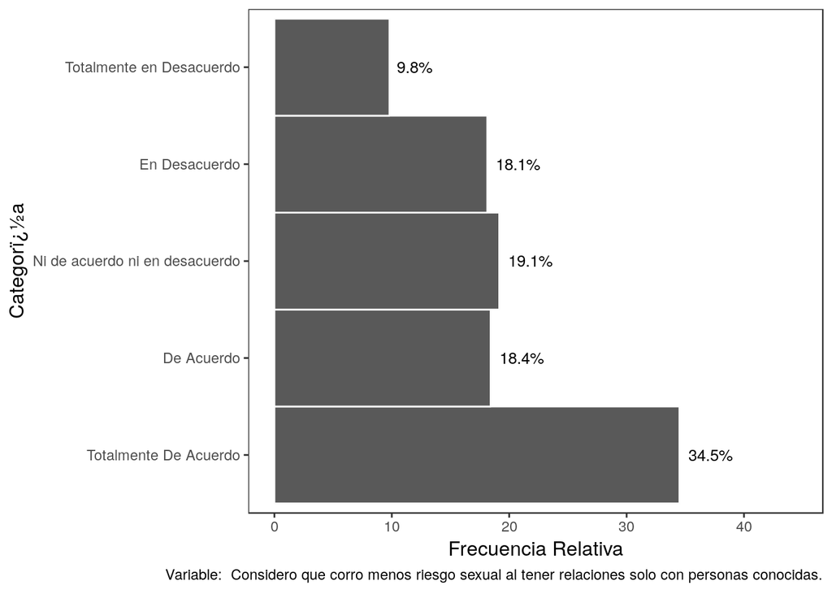

## Me siento más confiado al tener relaciones sexuales con alguien que tenga apariencia física saludable.

A continuaciï¿½n se presentan las estadï¿½sticas de la variable (`Me siento más confiado al tener relaciones sexuales con alguien que tenga apariencia física saludable.`)

Tabla de Frecuencia

| Categorï¿½a | Frecuencia abs | Frecuencia rel. (%) |
| --- | --- | --- |
| Totalmente De Acuerdo | 254 | 37.13 |
| De Acuerdo | 75 | 10.96 |
| Ni de acuerdo ni en desacuerdo | 169 | 24.71 |
| En Desacuerdo | 133 | 19.44 |
| Totalmente en Desacuerdo | 53 | 7.75 |

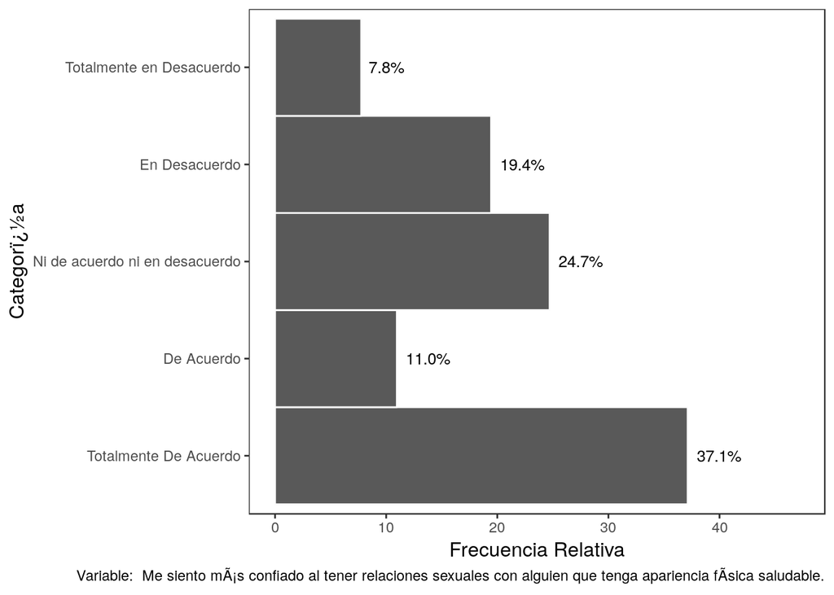

# Satisfacción sexual

A continuación se muestran los estadísticos descriptivos de las variables correspondientes a la satisfacción sexual de la muestra…

## Me importa el placer de la persona con la que tengo relaciones sexuales

A continuaciï¿½n se presentan las estadï¿½sticas de la variable (`Me importa el placer de la persona con la que tengo relaciones sexuales`)

Tabla de Frecuencia

| Categorï¿½a | Frecuencia abs | Frecuencia rel. (%) |
| --- | --- | --- |
| Siempre | 1 | 0.15 |
| Casi Siempre | 157 | 22.95 |
| Casi Nunca | 10 | 1.46 |
| Nunca | 516 | 75.44 |

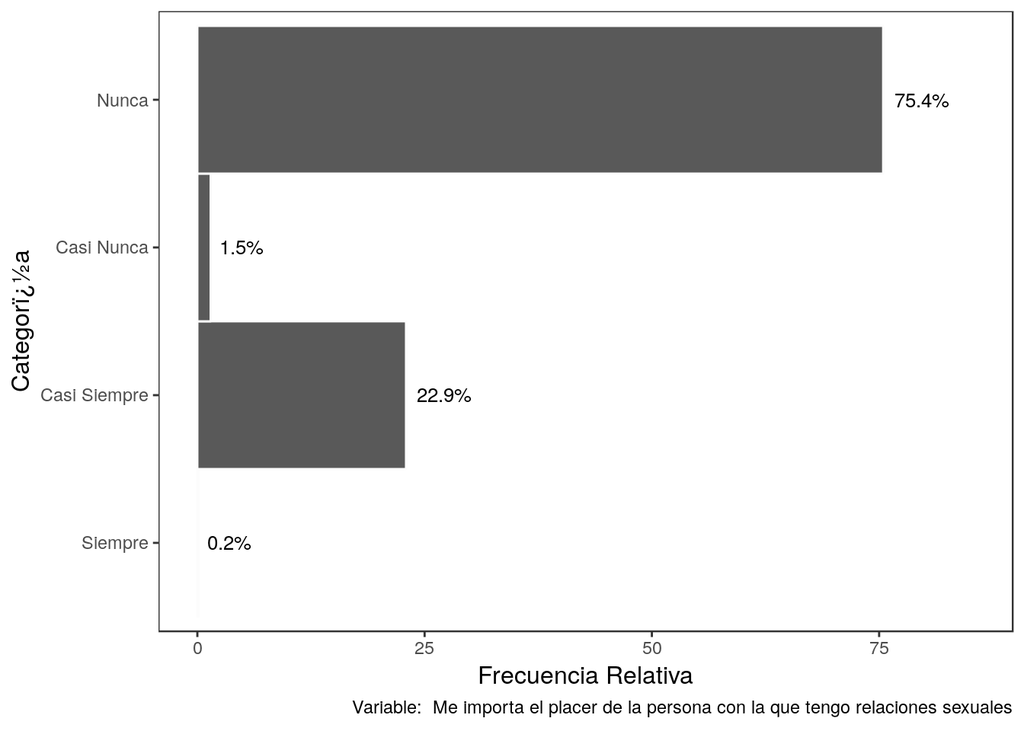

## Considero que mis experiencias sexuales son muy placenteras

A continuaciï¿½n se presentan las estadï¿½sticas de la variable (`Considero que mis experiencias sexuales son muy placenteras`)

Tabla de Frecuencia

| Categorï¿½a | Frecuencia abs | Frecuencia rel. (%) |
| --- | --- | --- |
| Siempre | 77 | 11.26 |
| Casi Siempre | 415 | 60.67 |
| Casi Nunca | 16 | 2.34 |
| Nunca | 176 | 25.73 |

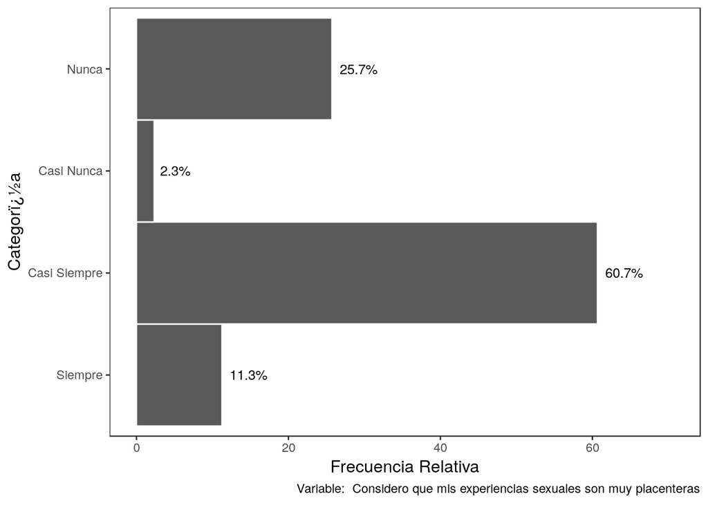

## Me incomoda manifestar placer

A continuaciï¿½n se presentan las estadï¿½sticas de la variable (`Me incomoda manifestar placer`)

Tabla de Frecuencia

| Categorï¿½a | Frecuencia abs | Frecuencia rel. (%) |
| --- | --- | --- |
| Siempre | 204 | 29.82 |
| Casi Siempre | 35 | 5.12 |
| Casi Nunca | 436 | 63.74 |
| Nunca | 9 | 1.32 |

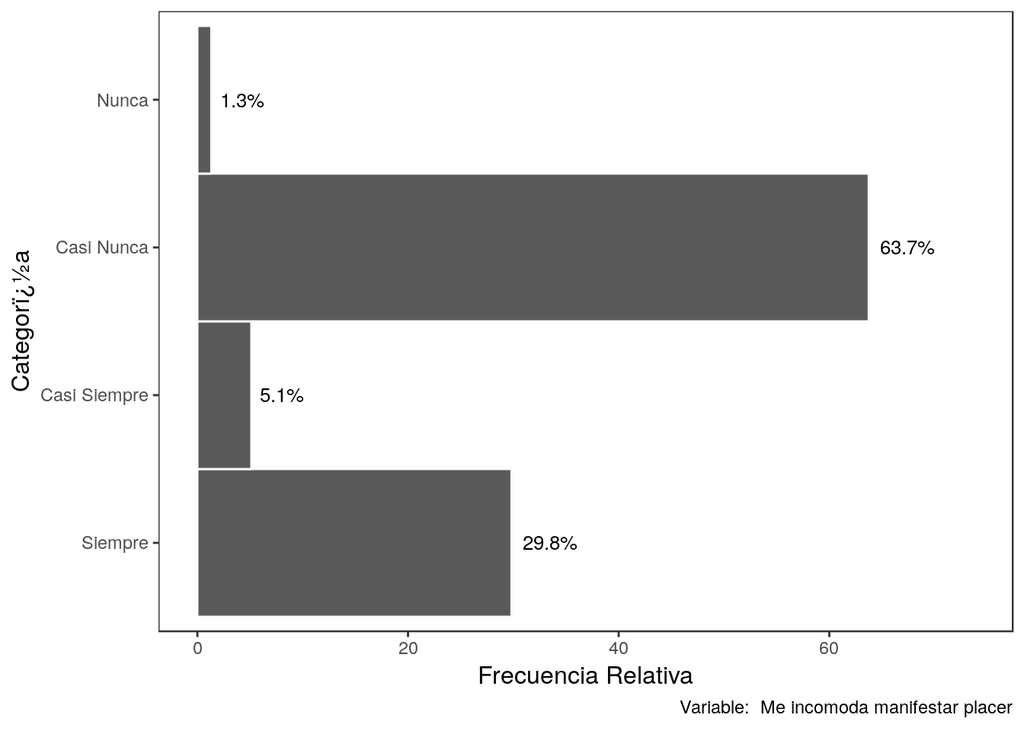

## En el momento de mis prácticas sexuales me inquieta no alcanzar el orgasmo rápidamente

A continuaciï¿½n se presentan las estadï¿½sticas de la variable (`En el momento de mis prácticas sexuales me inquieta no alcanzar el orgasmo rápidamente`)

Tabla de Frecuencia

| Categorï¿½a | Frecuencia abs | Frecuencia rel. (%) |
| --- | --- | --- |
| Siempre | 312 | 45.61 |
| Casi Siempre | 76 | 11.11 |
| Casi Nunca | 273 | 39.91 |
| Nunca | 23 | 3.36 |

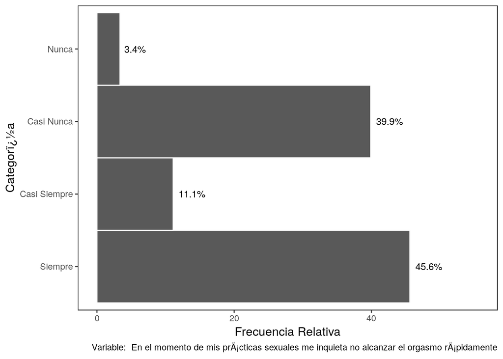

## Después de una relación sexual evito el contacto con la persona con quien estuve

A continuaciï¿½n se presentan las estadï¿½sticas de la variable (`Después de una relación sexual evito el contacto con la persona con quien estuve`)

Tabla de Frecuencia

| Categorï¿½a | Frecuencia abs | Frecuencia rel. (%) |
| --- | --- | --- |
| Siempre | 207 | 30.26 |
| Casi Siempre | 30 | 4.39 |
| Casi Nunca | 442 | 64.62 |
| Nunca | 5 | 0.73 |

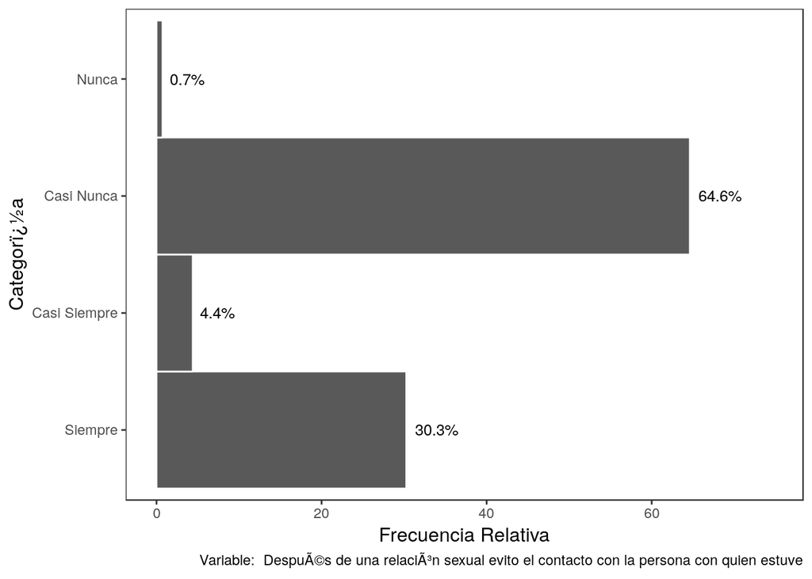

## En la relaciÃ³n sexual finjo tener un orgasmo para que la otra persona se sienta bien

A continuaciï¿½n se presentan las estadï¿½sticas de la variable (`En la relaciÃ³n sexual finjo tener un orgasmo para que la otra persona se sienta bien`)

Tabla de Frecuencia

| Categorï¿½a | Frecuencia abs | Frecuencia rel. (%) |
| --- | --- | --- |
| Siempre | 218 | 31.87 |
| Casi Siempre | 49 | 7.16 |
| Casi Nunca | 405 | 59.21 |
| Nunca | 12 | 1.75 |

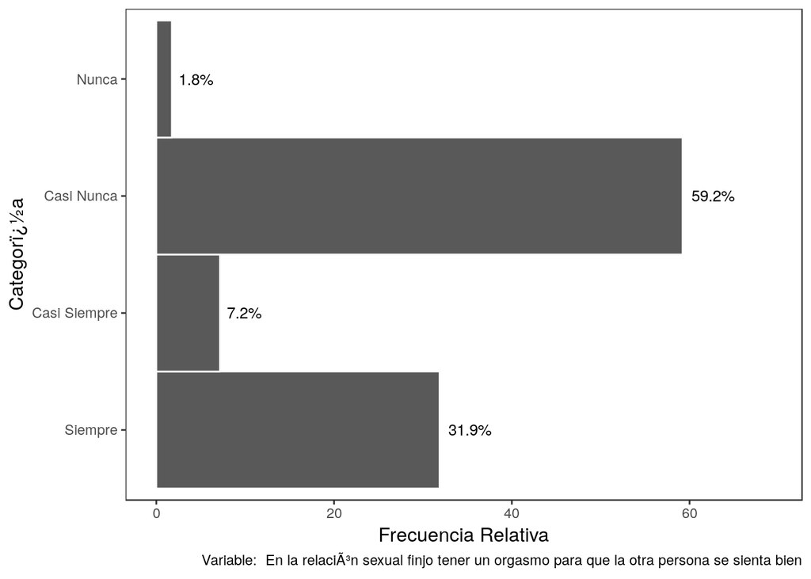

## Me considero buen(a) amante

A continuaciï¿½n se presentan las estadï¿½sticas de la variable (`Me considero buen(a) amante`)

Tabla de Frecuencia

| Categorï¿½a | Frecuencia abs | Frecuencia rel. (%) |
| --- | --- | --- |
| Siempre | 71 | 10.38 |
| Casi Siempre | 448 | 65.50 |
| Casi Nunca | 31 | 4.53 |
| Nunca | 134 | 19.59 |

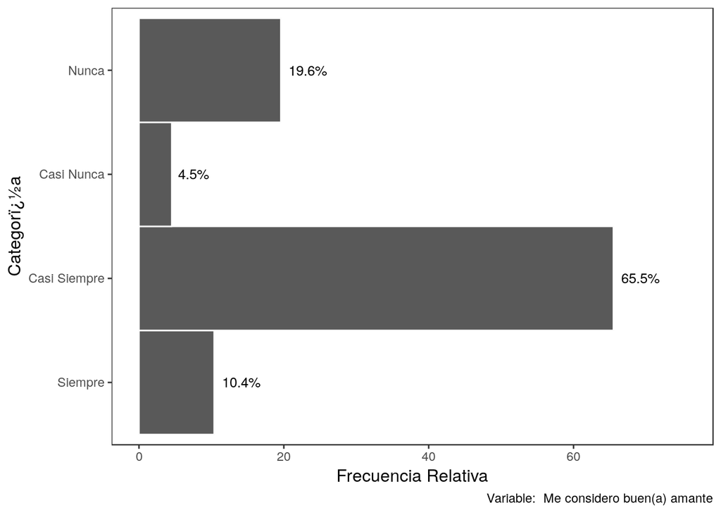

## Cuando tengo relaciones sexuales el movimiento con la otra persona es sincronizado

A continuaciï¿½n se presentan las estadï¿½sticas de la variable (`Cuando tengo relaciones sexuales el movimiento con la otra persona es sincronizado`)

Tabla de Frecuencia

| Categorï¿½a | Frecuencia abs | Frecuencia rel. (%) |
| --- | --- | --- |
| Siempre | 74 | 10.82 |
| Casi Siempre | 463 | 67.69 |
| Casi Nunca | 20 | 2.92 |
| Nunca | 127 | 18.57 |

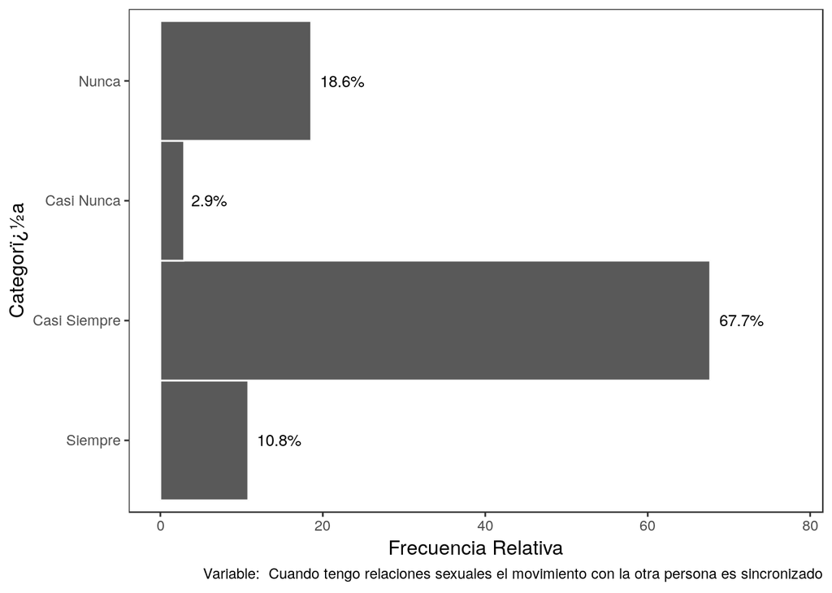

## He llorado por la inconformidad generada durante mis relaciones sexuales

A continuaciï¿½n se presentan las estadï¿½sticas de la variable (`He llorado por la inconformidad generada durante mis relaciones sexuales`)

Tabla de Frecuencia

| Categorï¿½a | Frecuencia abs | Frecuencia rel. (%) |
| --- | --- | --- |
| Siempre | 161 | 23.54 |
| Casi Siempre | 28 | 4.09 |
| Casi Nunca | 489 | 71.49 |
| Nunca | 6 | 0.88 |

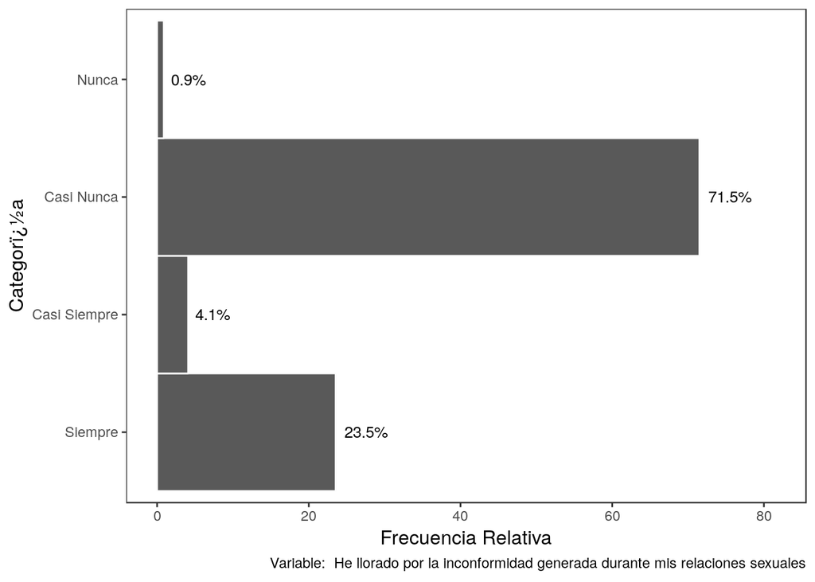

## Después de mis prácticas sexuales tengo un profundo sentimiento de soledad

A continuaciï¿½n se presentan las estadï¿½sticas de la variable (`Después de mis prácticas sexuales tengo un profundo sentimiento de soledad`)

Tabla de Frecuencia

| Categorï¿½a | Frecuencia abs | Frecuencia rel. (%) |
| --- | --- | --- |
| Siempre | 212 | 30.99 |
| Casi Siempre | 62 | 9.06 |
| Casi Nunca | 393 | 57.46 |
| Nunca | 17 | 2.49 |

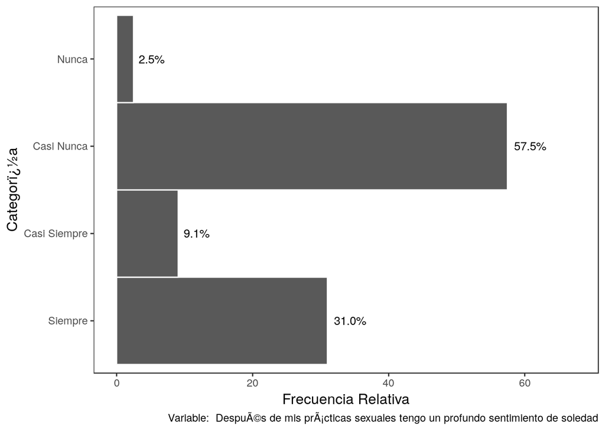

## Converso con la otra persona acerca de lo que nos produce placer

A continuaciï¿½n se presentan las estadï¿½sticas de la variable (`Converso con la otra persona acerca de lo que nos produce placer`)

Tabla de Frecuencia

| Categorï¿½a | Frecuencia abs | Frecuencia rel. (%) |
| --- | --- | --- |
| Siempre | 89 | 13.01 |
| Casi Siempre | 348 | 50.88 |
| Casi Nunca | 33 | 4.82 |
| Nunca | 214 | 31.29 |

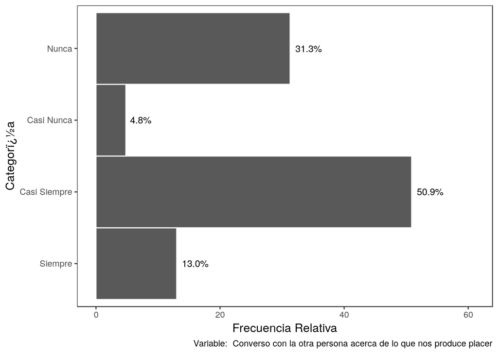

## Mis relaciones sexuales son apasionadas

A continuaciï¿½n se presentan las estadï¿½sticas de la variable (`Mis relaciones sexuales son apasionadas`)

Tabla de Frecuencia

| Categorï¿½a | Frecuencia abs | Frecuencia rel. (%) |
| --- | --- | --- |
| Siempre | 52 | 7.60 |
| Casi Siempre | 375 | 54.82 |
| Casi Nunca | 26 | 3.80 |
| Nunca | 231 | 33.77 |

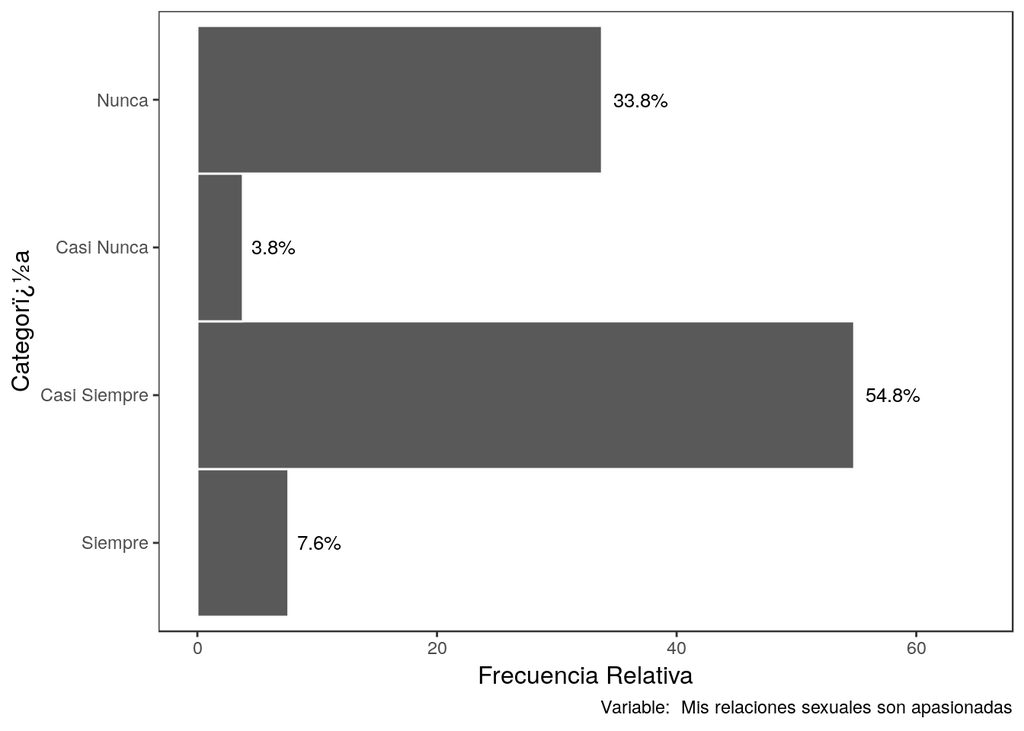

## Siento temor de decirle a la otra persona lo que me gusta sexualmente

A continuaciï¿½n se presentan las estadï¿½sticas de la variable (`Siento temor de decirle a la otra persona lo que me gusta sexualmente`)

Tabla de Frecuencia

| Categorï¿½a | Frecuencia abs | Frecuencia rel. (%) |
| --- | --- | --- |
| Siempre | 259 | 37.87 |
| Casi Siempre | 72 | 10.53 |
| Casi Nunca | 334 | 48.83 |
| Nunca | 19 | 2.78 |

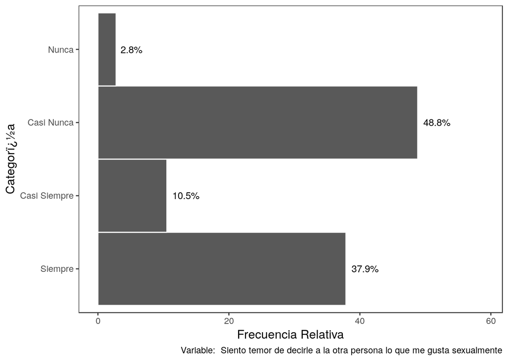

## Mis parejas me definen como buen(a) amante

A continuaciï¿½n se presentan las estadï¿½sticas de la variable (`Mis parejas me definen como buen(a) amante`)

Tabla de Frecuencia

| Categorï¿½a | Frecuencia abs | Frecuencia rel. (%) |
| --- | --- | --- |
| Siempre | 60 | 8.77 |
| Casi Siempre | 414 | 60.53 |
| Casi Nunca | 33 | 4.82 |
| Nunca | 177 | 25.88 |

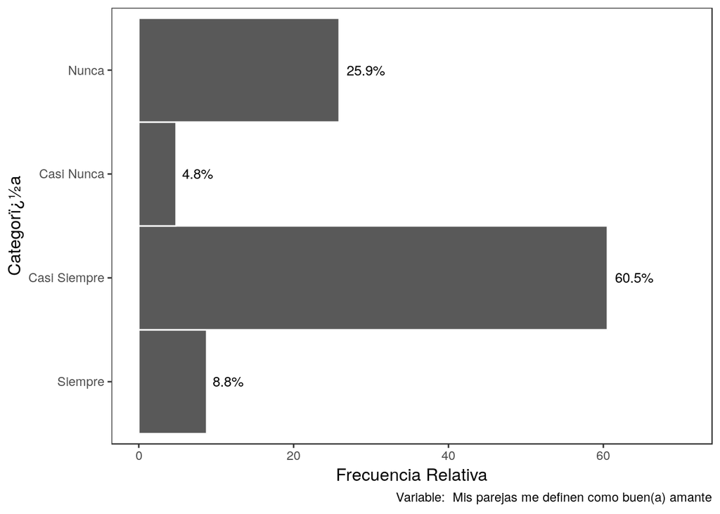

## Prolongo mi excitaciÃ³n hasta que la otra persona alcance el orgasmo

A continuaciï¿½n se presentan las estadï¿½sticas de la variable (`Prolongo mi excitaciÃ³n hasta que la otra persona alcance el orgasmo`)

Tabla de Frecuencia

| Categorï¿½a | Frecuencia abs | Frecuencia rel. (%) |
| --- | --- | --- |
| Siempre | 109 | 15.94 |
| Casi Siempre | 383 | 55.99 |
| Casi Nunca | 44 | 6.43 |
| Nunca | 148 | 21.64 |

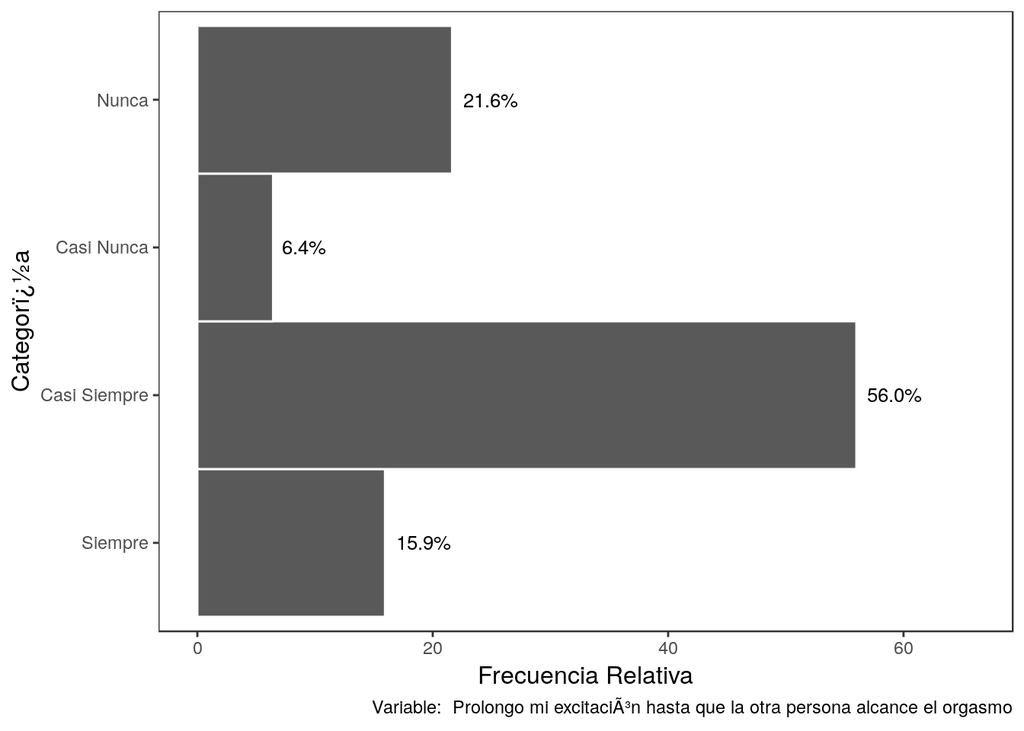

## Me siento culpable luego de tener una experiencia sexual

A continuaciï¿½n se presentan las estadï¿½sticas de la variable (`Me siento culpable luego de tener una experiencia sexual`)

Tabla de Frecuencia

| Categorï¿½a | Frecuencia abs | Frecuencia rel. (%) |
| --- | --- | --- |
| Siempre | 197 | 28.80 |
| Casi Siempre | 41 | 5.99 |
| Casi Nunca | 430 | 62.87 |
| Nunca | 16 | 2.34 |

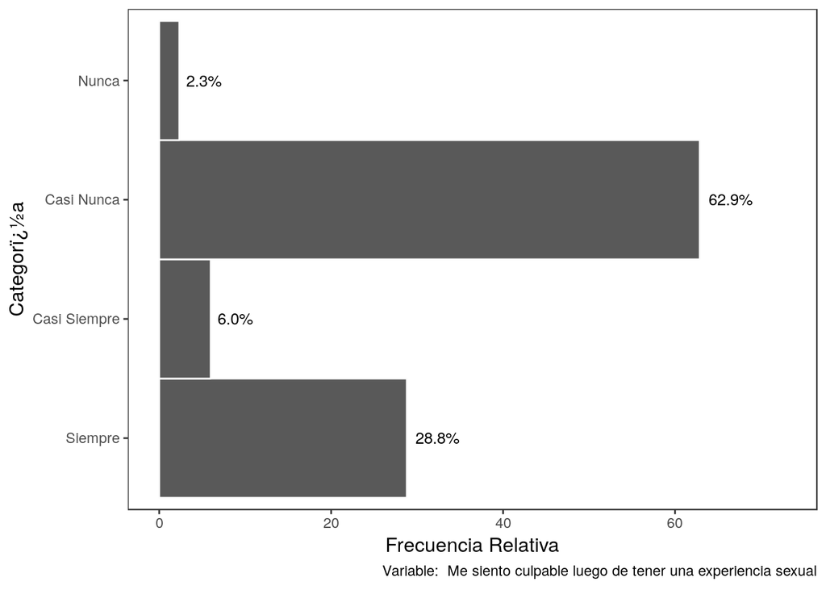

## Me reprocho algunas de mis experiencias sexuales

A continuaciï¿½n se presentan las estadï¿½sticas de la variable (`Me reprocho algunas de mis experiencias sexuales`)

Tabla de Frecuencia

| Categorï¿½a | Frecuencia abs | Frecuencia rel. (%) |
| --- | --- | --- |
| Siempre | 305 | 44.59 |
| Casi Siempre | 106 | 15.50 |
| Casi Nunca | 242 | 35.38 |
| Nunca | 31 | 4.53 |

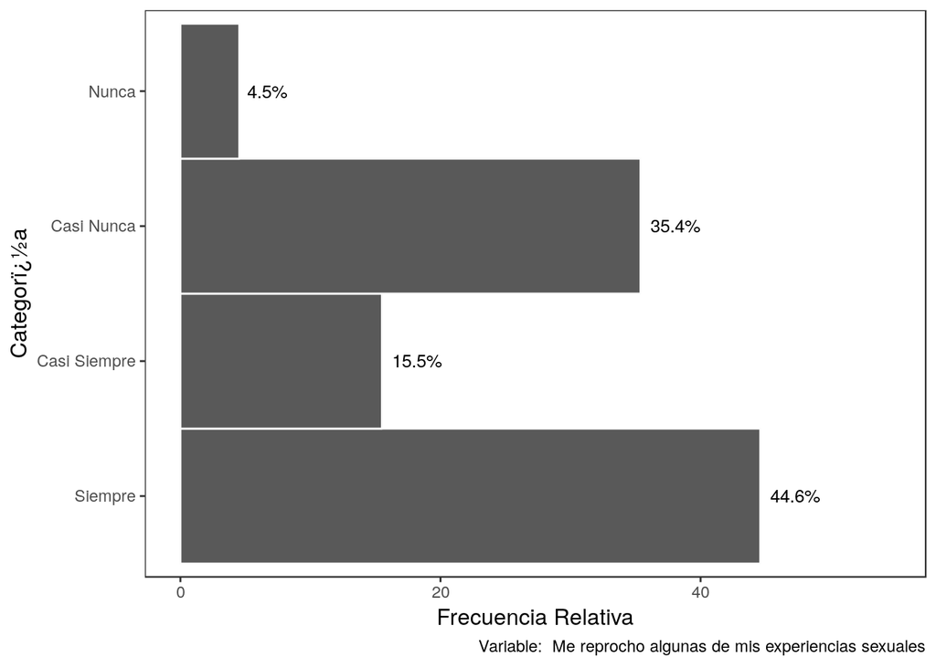

## Con mi pareja cumplimos nuestras expectativas al tener una relaciÃ³n sexual

A continuaciï¿½n se presentan las estadï¿½sticas de la variable (`Con mi pareja cumplimos nuestras expectativas al tener una relaciÃ³n sexual`)

Tabla de Frecuencia

| Categorï¿½a | Frecuencia abs | Frecuencia rel. (%) |
| --- | --- | --- |
| Siempre | 84 | 12.28 |
| Casi Siempre | 406 | 59.36 |
| Casi Nunca | 36 | 5.26 |
| Nunca | 158 | 23.10 |

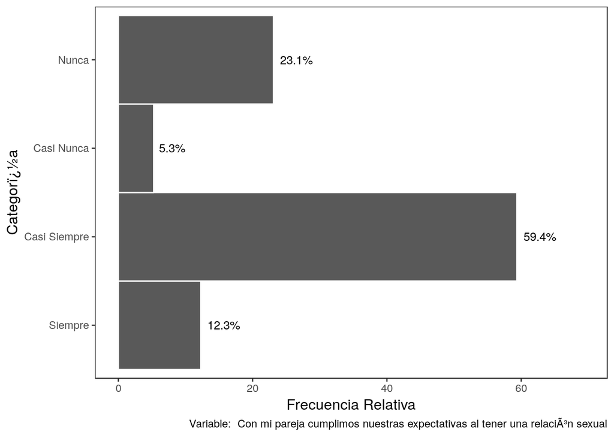

## Cuando estoy sexualmente con mi pareja siento una profunda conexiÃ³n

A continuaciï¿½n se presentan las estadï¿½sticas de la variable (`Cuando estoy sexualmente con mi pareja siento una profunda conexiÃ³n`)

Tabla de Frecuencia

| Categorï¿½a | Frecuencia abs | Frecuencia rel. (%) |
| --- | --- | --- |
| Siempre | 80 | 11.70 |
| Casi Siempre | 315 | 46.05 |
| Casi Nunca | 41 | 5.99 |
| Nunca | 248 | 36.26 |

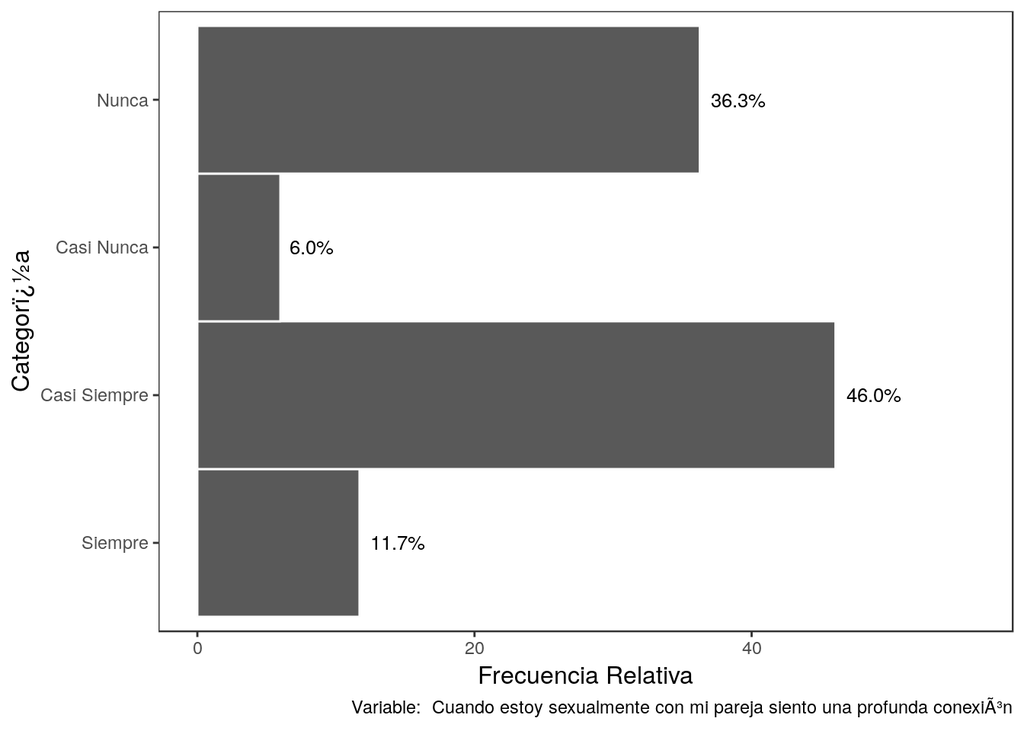

## Me entiendo con las personas con quienes tengo relaciones sexuales

A continuaciï¿½n se presentan las estadï¿½sticas de la variable (`Me entiendo con las personas con quienes tengo relaciones sexuales`)

Tabla de Frecuencia

| Categorï¿½a | Frecuencia abs | Frecuencia rel. (%) |
| --- | --- | --- |
| Siempre | 66 | 9.65 |
| Casi Siempre | 399 | 58.33 |
| Casi Nunca | 20 | 2.92 |
| Nunca | 199 | 29.09 |

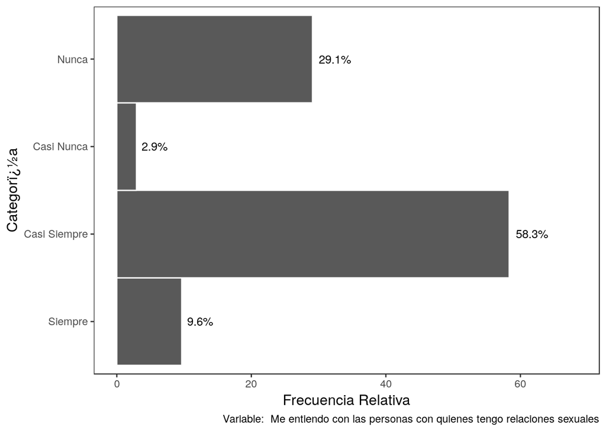

## En mis relaciones sexuales logro desinhibirme por completo

A continuaciï¿½n se presentan las estadï¿½sticas de la variable (`En mis relaciones sexuales logro desinhibirme por completo`)

Tabla de Frecuencia

| Categorï¿½a | Frecuencia abs | Frecuencia rel. (%) |
| --- | --- | --- |
| Siempre | 127 | 18.57 |
| Casi Siempre | 380 | 55.56 |
| Casi Nunca | 43 | 6.29 |
| Nunca | 134 | 19.59 |

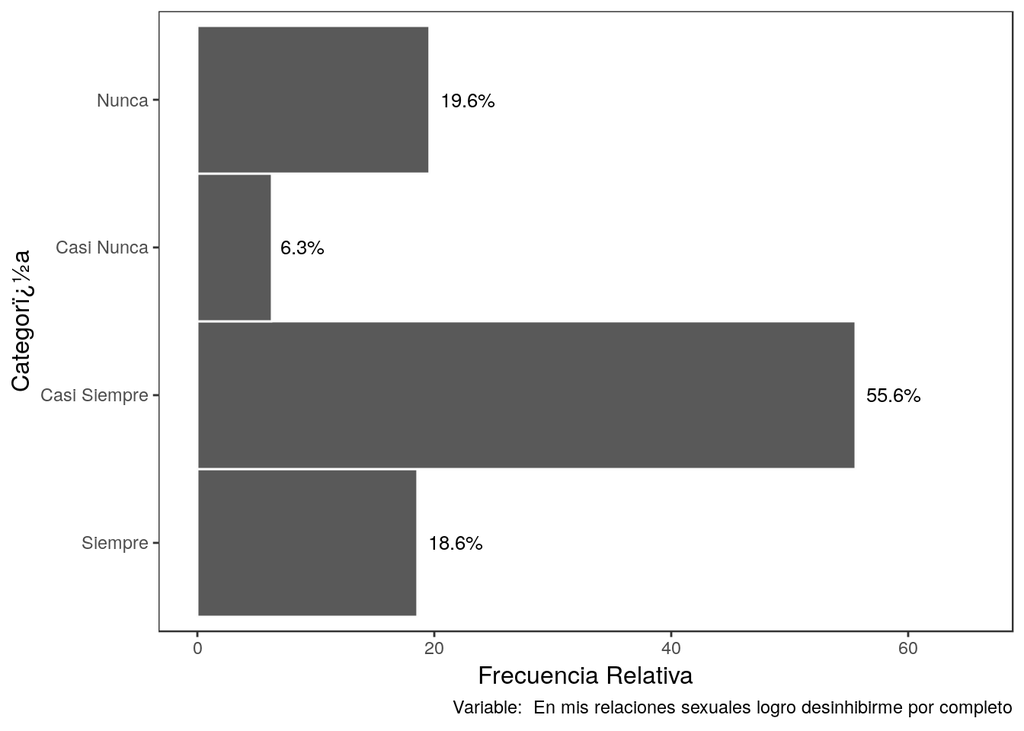

## Considero que mis relaciones sexuales son muy creativas

A continuaciï¿½n se presentan las estadï¿½sticas de la variable (`Considero que mis relaciones sexuales son muy creativas`)

Tabla de Frecuencia

| Categorï¿½a | Frecuencia abs | Frecuencia rel. (%) |
| --- | --- | --- |
| Siempre | 217 | 31.73 |
| Casi Siempre | 337 | 49.27 |
| Casi Nunca | 52 | 7.60 |
| Nunca | 78 | 11.40 |

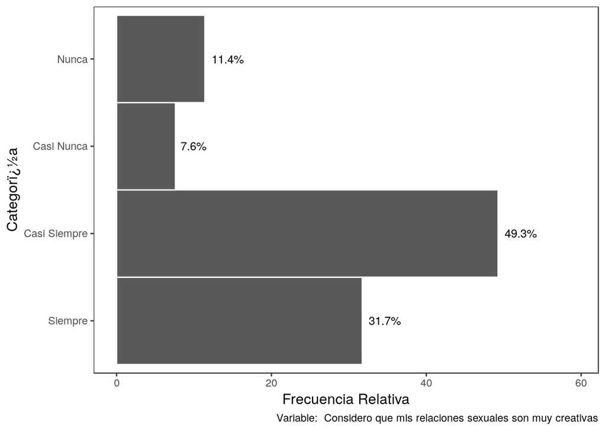

## Después de una relación sexual tengo una sensación de plenitud

A continuaciï¿½n se presentan las estadï¿½sticas de la variable (`Después de una relación sexual tengo una sensación de plenitud`)

Tabla de Frecuencia

| Categorï¿½a | Frecuencia abs | Frecuencia rel. (%) |
| --- | --- | --- |
| Siempre | 140 | 20.47 |
| Casi Siempre | 368 | 53.80 |
| Casi Nunca | 32 | 4.68 |
| Nunca | 144 | 21.05 |

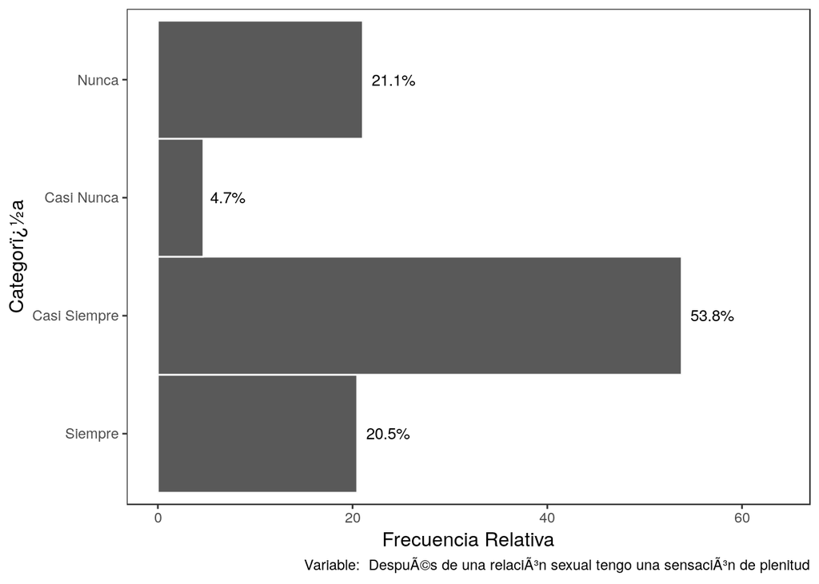

## En mis relaciones sexuales suelo concentrarme en la penetraciÃ³n descuidado otros aspectos

A continuaciï¿½n se presentan las estadï¿½sticas de la variable (`En mis relaciones sexuales suelo concentrarme en la penetraciÃ³n descuidado otros aspectos`)

Tabla de Frecuencia

| Categorï¿½a | Frecuencia abs | Frecuencia rel. (%) |
| --- | --- | --- |
| Siempre | 363 | 53.07 |
| Casi Siempre | 98 | 14.33 |
| Casi Nunca | 212 | 30.99 |
| Nunca | 11 | 1.61 |

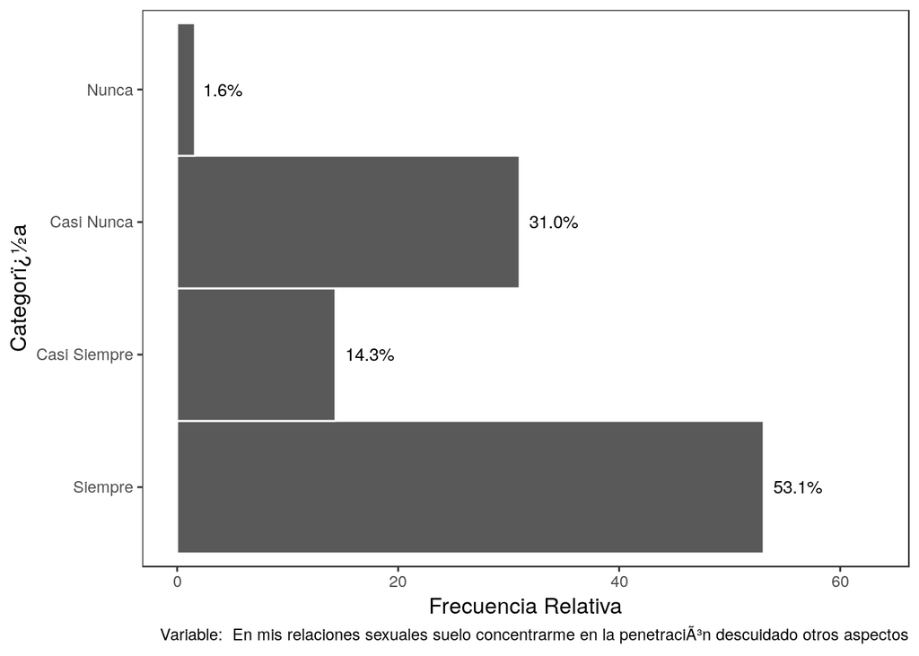

## He notado poco interÃ©s hacia mis relaciones sexuales

A continuaciï¿½n se presentan las estadï¿½sticas de la variable (`He notado poco interÃ©s hacia mis relaciones sexuales`)

Tabla de Frecuencia

| Categorï¿½a | Frecuencia abs | Frecuencia rel. (%) |
| --- | --- | --- |
| Siempre | 322 | 47.08 |
| Casi Siempre | 76 | 11.11 |
| Casi Nunca | 269 | 39.33 |
| Nunca | 17 | 2.49 |

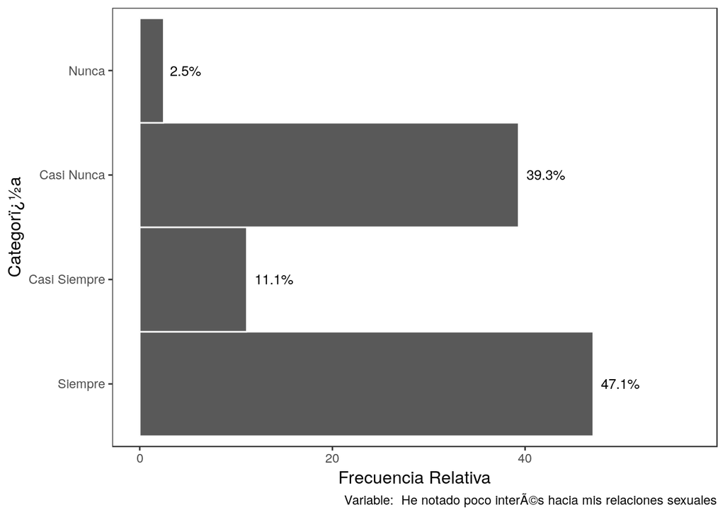

## Me involucro con todos mis sentidos cuando tengo una relaciÃ³n sexual

A continuaciï¿½n se presentan las estadï¿½sticas de la variable (`Me involucro con todos mis sentidos cuando tengo una relaciÃ³n sexual`)

Tabla de Frecuencia

| Categorï¿½a | Frecuencia abs | Frecuencia rel. (%) |
| --- | --- | --- |
| Siempre | 98 | 14.33 |
| Casi Siempre | 358 | 52.34 |
| Casi Nunca | 20 | 2.92 |
| Nunca | 208 | 30.41 |

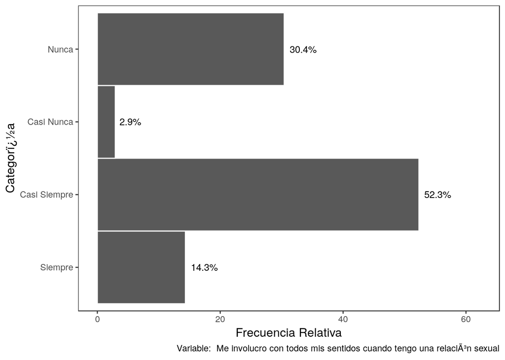

## Pienso en otras cosas cuando tengo una prÃ¡ctica sexual

A continuaciï¿½n se presentan las estadï¿½sticas de la variable (`Pienso en otras cosas cuando tengo una prÃ¡ctica sexual`)

Tabla de Frecuencia

| Categorï¿½a | Frecuencia abs | Frecuencia rel. (%) |
| --- | --- | --- |
| Siempre | 396 | 57.89 |
| Casi Siempre | 108 | 15.79 |
| Casi Nunca | 163 | 23.83 |
| Nunca | 17 | 2.49 |

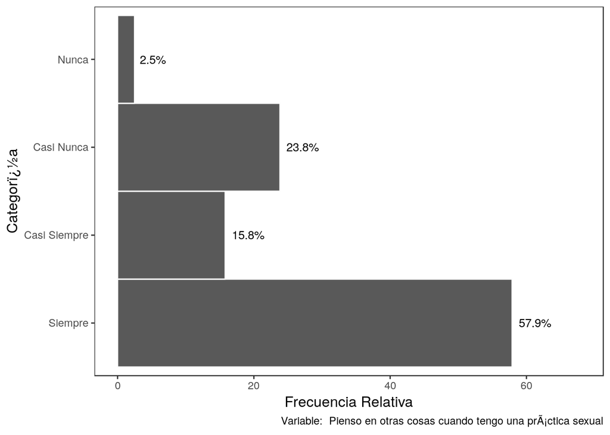

## Cuando tengo una relaciÃ³n sexual espero que pronto se acabe

A continuaciï¿½n se presentan las estadï¿½sticas de la variable (`Cuando tengo una relaciÃ³n sexual espero que pronto se acabe`)

Tabla de Frecuencia

| Categorï¿½a | Frecuencia abs | Frecuencia rel. (%) |
| --- | --- | --- |
| Siempre | 278 | 40.64 |
| Casi Siempre | 49 | 7.16 |
| Casi Nunca | 349 | 51.02 |
| Nunca | 8 | 1.17 |

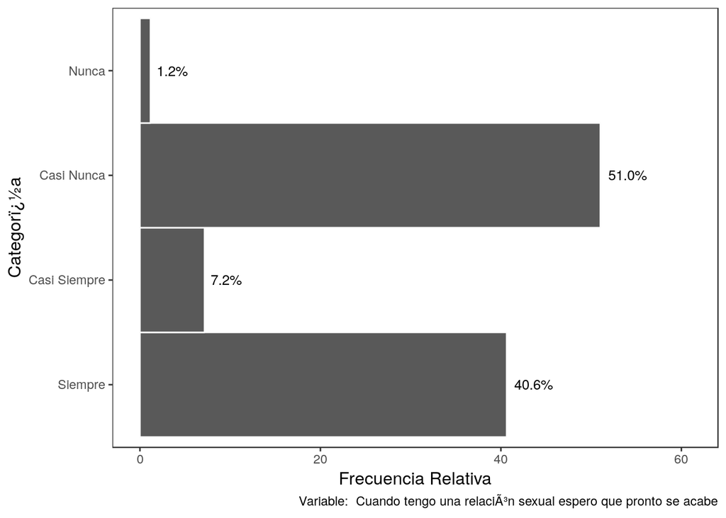

## Suelo preguntarme por qué accedí a tener una relación sexual con alguien

A continuaciï¿½n se presentan las estadï¿½sticas de la variable (`Suelo preguntarme por qué accedí a tener una relación sexual con alguien`)

Tabla de Frecuencia

| Categorï¿½a | Frecuencia abs | Frecuencia rel. (%) |
| --- | --- | --- |
| Siempre | 228 | 33.33 |
| Casi Siempre | 74 | 10.82 |
| Casi Nunca | 355 | 51.90 |
| Nunca | 27 | 3.95 |

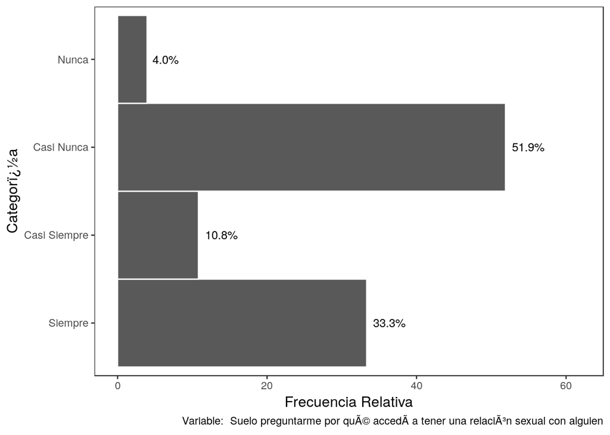

## Luego de una relaciÃ³n sexual siento como si no hubiera ocurrido

A continuaciï¿½n se presentan las estadï¿½sticas de la variable (`Luego de una relaciÃ³n sexual siento como si no hubiera ocurrido`)

Tabla de Frecuencia

| Categorï¿½a | Frecuencia abs | Frecuencia rel. (%) |
| --- | --- | --- |
| Siempre | 202 | 29.53 |
| Casi Siempre | 40 | 5.85 |
| Casi Nunca | 434 | 63.45 |
| Nunca | 8 | 1.17 |

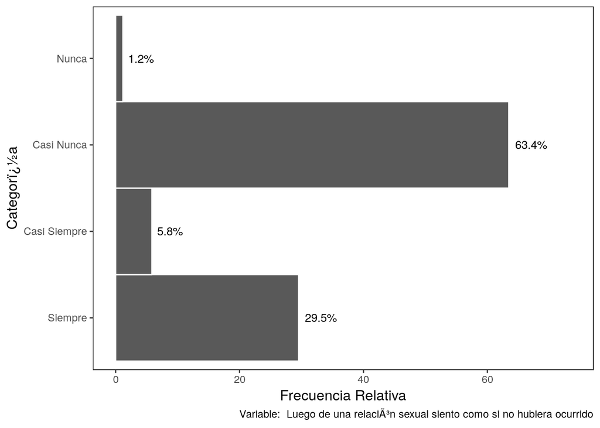

## Cuando amo tanto a las personas con las que me relaciono sexualmente me obligo a realizar lo que no deseo para satisfacerle

A continuaciï¿½n se presentan las estadï¿½sticas de la variable (`Cuando amo tanto a las personas con las que me relaciono sexualmente me obligo a realizar lo que no deseo para satisfacerle`)

Tabla de Frecuencia

| Categorï¿½a | Frecuencia abs | Frecuencia rel. (%) |
| --- | --- | --- |
| Siempre | 216 | 31.58 |
| Casi Siempre | 64 | 9.36 |
| Casi Nunca | 384 | 56.14 |
| Nunca | 20 | 2.92 |

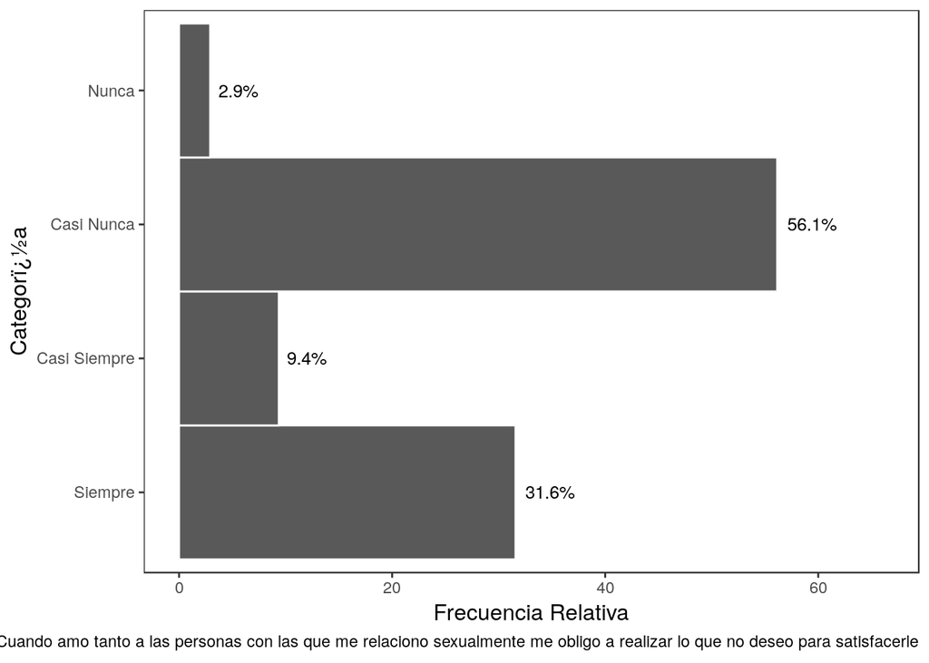

## Cuando tengo relaciones sexuales cada cual lleva su propio ritmo

A continuaciï¿½n se presentan las estadï¿½sticas de la variable (`Cuando tengo relaciones sexuales cada cual lleva su propio ritmo`)

Tabla de Frecuencia

| Categorï¿½a | Frecuencia abs | Frecuencia rel. (%) |
| --- | --- | --- |
| Siempre | 376 | 54.97 |
| Casi Siempre | 103 | 15.06 |
| Casi Nunca | 187 | 27.34 |
| Nunca | 18 | 2.63 |

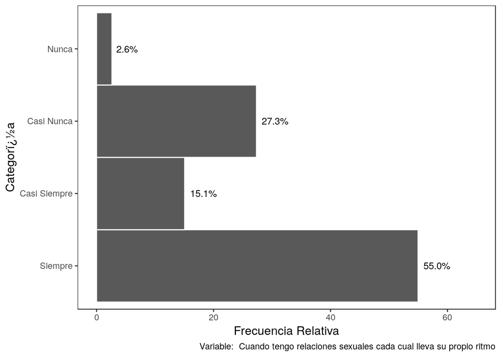

## Después de mis prácticas sexuales sonrío plácidamente

A continuaciï¿½n se presentan las estadï¿½sticas de la variable (`Después de mis prácticas sexuales sonrío plácidamente`)

Tabla de Frecuencia

| Categorï¿½a | Frecuencia abs | Frecuencia rel. (%) |
| --- | --- | --- |
| Siempre | 96 | 14.04 |
| Casi Siempre | 354 | 51.75 |
| Casi Nunca | 35 | 5.12 |
| Nunca | 199 | 29.09 |

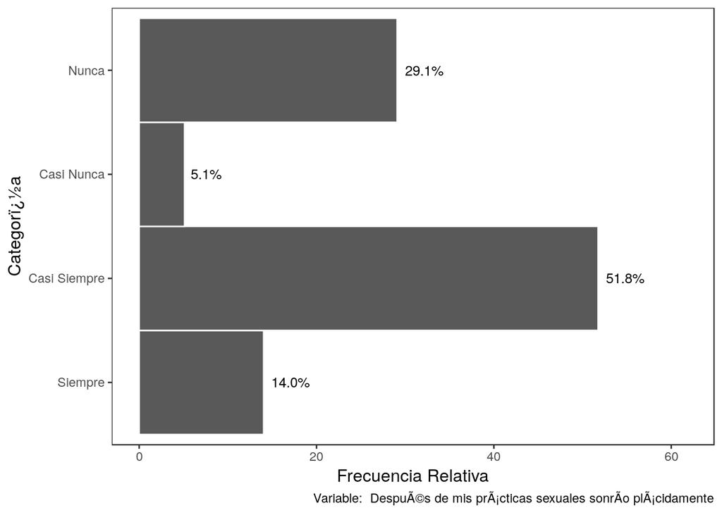